# Explore Translation Comparison Approaches

Author

J. Allen Baron

**Show R packages, source functions, and google sheet input**

```r
library(here)
library(googlesheets4)
library(dplyr)
library(readr)
library(tidyr)
library(ggplot2)
library(purrr)
library(stringdist)
library(pwalign) # install using BiocManager v3.19
library(tokenizers)
library(stopwords)

source(here::here("scripts/function-str_similar.R"))
source(here::here("scripts/function-word_similar.R"))
source(here::here("scripts/function-utils-numeric.R"))

# Disorder_compare_en_es google sheet with translation data
gs <- "1Fvnmz_3KNXuLvLtJGm9eKkqvV33mIZUESsPWv28uUAg"
```

**Show the qgram_vary() function, used to calculate string distances at multiple q values.**

```r
qgram_vary <- function(df, col1, col2, q) {
    stringdist_methods <- c("qgram", "cos", "jaccard")

    .c1 <- tidyselect::eval_select(dplyr::enquo(col1), data = df)
    .c2 <- tidyselect::eval_select(dplyr::enquo(col2), data = df)

    .l <- purrr::map(
        stringdist_methods,
        function(.m) {
            purrr::map(
                q,
                ~ stringdist::stringsim(df[[.c1]], df[[.c2]], q = .x, method = .m)
            ) |>
                purrr::set_names(q)
        }
    ) |>
        purrr::set_names(paste0("en_", stringdist_methods)) |>
        unlist(recursive = FALSE)

    dplyr::bind_cols(df, .l)
}
```

# LABELS

## String-based Comparisons

I suspect some differences are related to case, spacing, number formats, or punctuation and will identify any of those strings that match after one or more of these transformations as high quality, along with noting in a column named `match_en` what transformations were needed to make them exact matches. Those that truly are exact, will be labelled as such.

Additionally, I will explore string-based distance metrics as a way to calculate translation quality, though I suspect these measures will not perform well.

I calculate a few different distance measures using the `stringdist` package and save the file so I can take a look at them.

```r
# label data from google sheet
label_init <- googlesheets4::with_gs4_quiet(
    googlesheets4::read_sheet(gs, "disorder_en_es_label")
)
```

```r
# file to save to
scomp_file <- here::here("data/research/explore_stringdist_metrics.csv")

label_scomp <- label_init |>
    dplyr::mutate(
        # good for single substitution errors
        en_osa = stringdist::stringsim(label, google_translate_to_en),
         # should be better than osa where more transpositions occur
        en_dl = stringdist::stringsim(label, google_translate_to_en, method = "dl"),
        # should be better for translation, most changes will be at substring level
        en_qgram = stringdist::stringsim(
            label,
            google_translate_to_en,
            method = "qgram"
        ),
        en_cos = stringdist::stringsim(
            label,
            google_translate_to_en,
            method = "cosine"
        ),
        en_jaccard = stringdist::stringsim(
            label,
            google_translate_to_en,
            method = "jaccard"
        ),
        .after = google_translate_to_en
    ) |>
    dplyr::mutate(
        review_notes = NA,
        cause = NA,
        match_en = str_similar(label, google_translate_to_en),
        quality = dplyr::if_else(!is.na(match_en), 5, NA_integer_),
        .before = 1
    )

# save only first time script is run, to avoid overwriting manually added info
if (!file.exists(scomp_file)) {
    readr::write_csv(label_scomp, scomp_file, na = "")
}
```

Since most matches are exact (75.42%), I’ll quickly review those that aren’t so I have a better ground truth for translation accuracy and issues…

I added quality scores manually in the existing `quality` column and added curate match info to a new column nmaed `cur_match_en`. Now I reload the data and calculate the difference between the string distances and the manually curated quality (by calculating R<sup>2</sup>).

**Show read_scomp_file() function**

```r
read_scomp_file <- function() {
    readr::read_csv(
        scomp_file,
        col_types = readr::cols(
            review_notes = readr::col_character(),
            cause = readr::col_character(),
            match_en = readr::col_character(),
            quality = readr::col_double(),
            class = readr::col_character(),
            label = readr::col_character(),
            google_translate_to_en = readr::col_character(),
            en_osa = readr::col_double(),
            en_dl = readr::col_double(),
            en_qgram = readr::col_double(),
            en_cos = readr::col_double(),
            en_jaccard = readr::col_double(),
            compare_en = readr::col_character(),
            clase = readr::col_character(),
            etiqueta = readr::col_character(),
            google_translate_to_es = readr::col_character(),
            compare_es = readr::col_character()
        )
    )
}
```

```r
label_smetric <- read_scomp_file()

# calculate difference of string measures to manual curation (R^2)
label_smetric |>
    dplyr::summarize(
        dplyr::across(
            dplyr::starts_with("en_"),
            ~ cor(.x, quality) ^ 2
        )
    ) |>
    tidyr::pivot_longer(
        cols = dplyr::everything(),
        names_to = "method",
        values_to = "r-squared",
        names_prefix = "en_"
    )
```

| method | r-squared |
| --- | --- |
| osa | 0.1279606 |
| dl | 0.1279606 |
| qgram | 0.2455431 |
| cos | 0.1344002 |
| jaccard | 0.2220769 |

The string-based approach doesn’t work very well, as expected. In order of goodness in prediction: qgram > jaccard > cos ~ osa ~ dl (none of these last are very good). The high number of exact matches are likely affecting this calculation. It is probably also heavily affected by a few big discrepancies (partially due to undesirable rearrangements).

### Plot

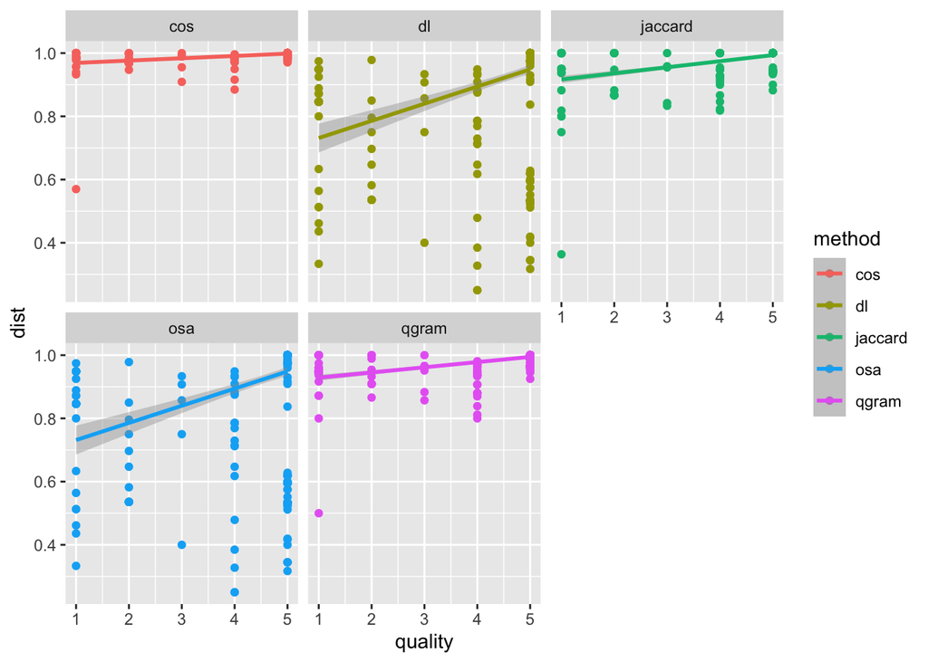

```r
label_smetric |>
    tidyr::pivot_longer(
        cols = dplyr::starts_with("en_"),
        names_to = "method",
        values_to = "dist",
        names_prefix = "en_"
    ) |>
    ggplot2::ggplot(ggplot2::aes(x = quality, y = dist, color = method)) +
    ggplot2::geom_point() +
    stat_smooth(method = "lm", formula = y ~ x) +
    ggplot2::facet_wrap(~ method)
```

The plot makes it clear that there’s not a good relationship between my manual rating and the string distance metrics.

### Q-value Exploration

**QUESTION:** qgram, jaccard, & cosine are all dependent on qgram size (default: 1); what happens if the qgram size is increased?

*Instead of a single character-based comparison, this becomes more of a character set-based comparison, though not word-based.*

```r
label_qgram <- label_smetric |>
    qgram_vary(label, google_translate_to_en, q = 1:10) |>
    dplyr::select(quality, dplyr::matches("en_[^.]+.[0-9]+$")) |>
    tidyr::pivot_longer(
        cols = dplyr::starts_with("en_"),
        names_to = c("method", "q"),
        values_to = "dist",
        names_pattern = "en_([^.]+).([0-9]+)",
        names_transform = list(q = as.integer)
    ) |>
    dplyr::mutate(dist = dplyr::if_else(is.na(dist), 0, dist))

label_qgram |>
    dplyr::summarize(
        "r-squared" = stats::cor(quality, dist) ^ 2,
        .by = c(method, q)
    ) |>
    tidyr::pivot_wider(
        names_from = method,
        values_from = "r-squared"
    )
```

| q | qgram | cos | jaccard |
| --- | --- | --- | --- |
| 1 | 0.2455431 | 0.1344002 | 0.2220769 |
| 2 | 0.3296961 | 0.3066611 | 0.3348642 |
| 3 | 0.3815547 | 0.3777306 | 0.3904509 |
| 4 | 0.3906432 | 0.3914335 | 0.4106941 |
| 5 | 0.3800990 | 0.3805153 | 0.3902915 |
| 6 | 0.3624237 | 0.3626615 | 0.3723706 |
| 7 | 0.3456563 | 0.3457439 | 0.3589727 |
| 8 | 0.3281732 | 0.3281538 | 0.3470705 |
| 9 | 0.3129210 | 0.3128030 | 0.3388111 |
| 10 | 0.2854616 | 0.2853070 | 0.3378021 |

The best R<sup>2</sup> value exists when q = 4 for all 3 measures. None even break 0.5 though.

#### Plot

The data is clearly more spread out, but not in the pattern you’d expect. The correlation between my manual scoring and the string distance metrics just isn’t there and brute-force attempts to improve it are not going to be meaningful.

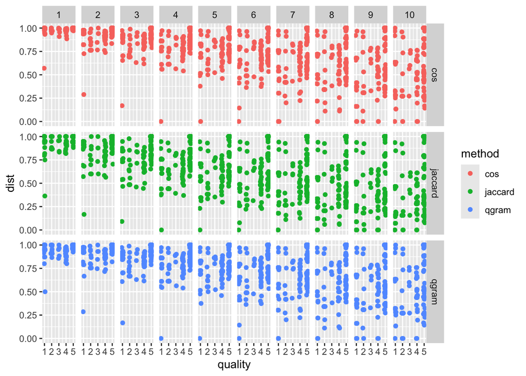

```r
ggplot2::ggplot(label_qgram) +
    ggplot2::geom_jitter(
        ggplot2::aes(x = quality, y = dist, color = method),
        height = 0, width = 0.1
    ) +
    ggplot2::facet_grid(method ~ q)
```

I wonder if we should train an ML model to identify problematic translations for us?

## Alignment

Given the rearrangements and high exact matches, it seemed that text alignment might be a good option for comparison. It makes sense to do a global alignment to include everything.

```r
label_scomp2 <- read_scomp_file() |>
    dplyr::select(-dplyr::starts_with("en_")) |>
    # no point in aligning exact matches
    dplyr::filter(match_en != "exact" | is.na(match_en))

g_alignment <- pwalign::pairwiseAlignment(
    label_scomp2$label,
    label_scomp2$google_translate_to_en,
    type = "global"
)

label_align <- label_scomp2 |>
    dplyr::mutate(
        g_align = paste0(
            as.character(pwalign::alignedPattern(g_alignment)), "\n",
            as.character(pwalign::alignedSubject(g_alignment))
        ),
        g_score = pwalign::score(g_alignment)
    )
```

The first few alignments look as expected but it seems like there are more spaces than necessary because these are character-based alignments and not word-based alignments. I don’t know of any algorithms for word-based alignments.

```
congenital ---------------nervous system abnormality
congenital anomaly of the nervous system------------

 congenital disorder of glycosylation--------- type I
congenital ------------glycosylation disorder type I

 congenital disorder of glycosylation---------
congenital ------------glycosylation disorder

 congenital disorder of glycosylation--------- type II
congenital ------------glycosylation disorder type II

 atrioventricular septal defect
atri----------al septal defect

 heart--- septal defect
c-ardiac septal defect
```

Since alignment scores are length dependent, it’s probably a good idea when trying to identify those that are best to institute some sort of length correction.

**Show r-squared code**

```r
galign_r2 <- label_align |>
    dplyr::summarize(accuracy = cor(quality, g_score) ^ 2) |>
    dplyr::pull(accuracy) |>
    round(digits = 6) |>
    format(scientific = FALSE)
```

The R<sup>2</sup> value for these alignments is way worse than for the string distance metrics (R<sup>2</sup> = 0.000024).

#### Plot

Yep, the line fit on the plot is flat. Not good.

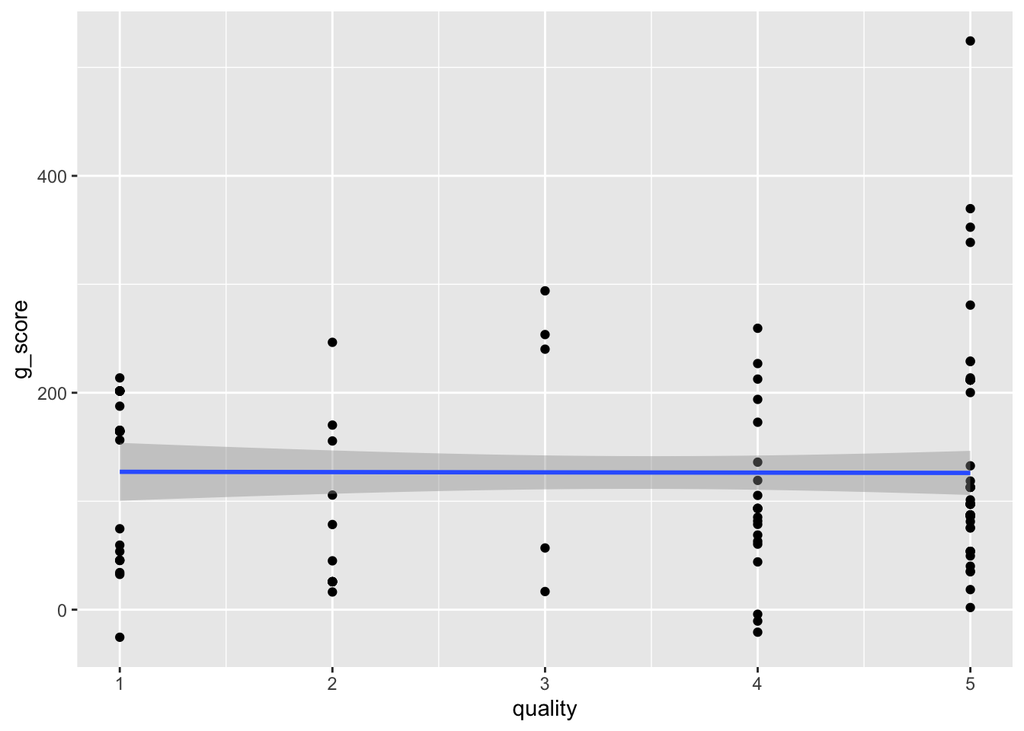

```r
ggplot2::ggplot(label_align, ggplot2::aes(x = quality, y = g_score)) +
    ggplot2::geom_point() +
    ggplot2::geom_smooth(method = "lm", formula = y ~ x)
```

Well, that doesn’t seem to work well, maybe primarily because of rearrangements that occur.

### Varying Alignment Type

It’s possible that other alignment types might work better. I’m going to test that really quickly, using various alignments provided by `pwalign::pairwiseAlignment()`.

```r
align_type <- c("global", "local", "overlap", "global-local", "local-global")

label_all_pw <- purrr::map(
    align_type,
    ~ pwalign::pairwiseAlignment(
        label_scomp2$label,
        label_scomp2$google_translate_to_en,
        type = .x
    )
)

label_alignments <- purrr::map(
    label_all_pw,
    ~ paste0(
        as.character(pwalign::alignedPattern(.x)), "\n",
        as.character(pwalign::alignedSubject(.x))
    )
)|>
    purrr::set_names(paste0(align_type, "_alignment"))

label_align_scores <- purrr::map(label_all_pw, pwalign::score) |>
    purrr::set_names(paste0(align_type, "_score"))

label_align_all <- label_scomp2 |>
    dplyr::bind_cols(label_alignments, label_align_scores)
```

This doesn’t look any better.

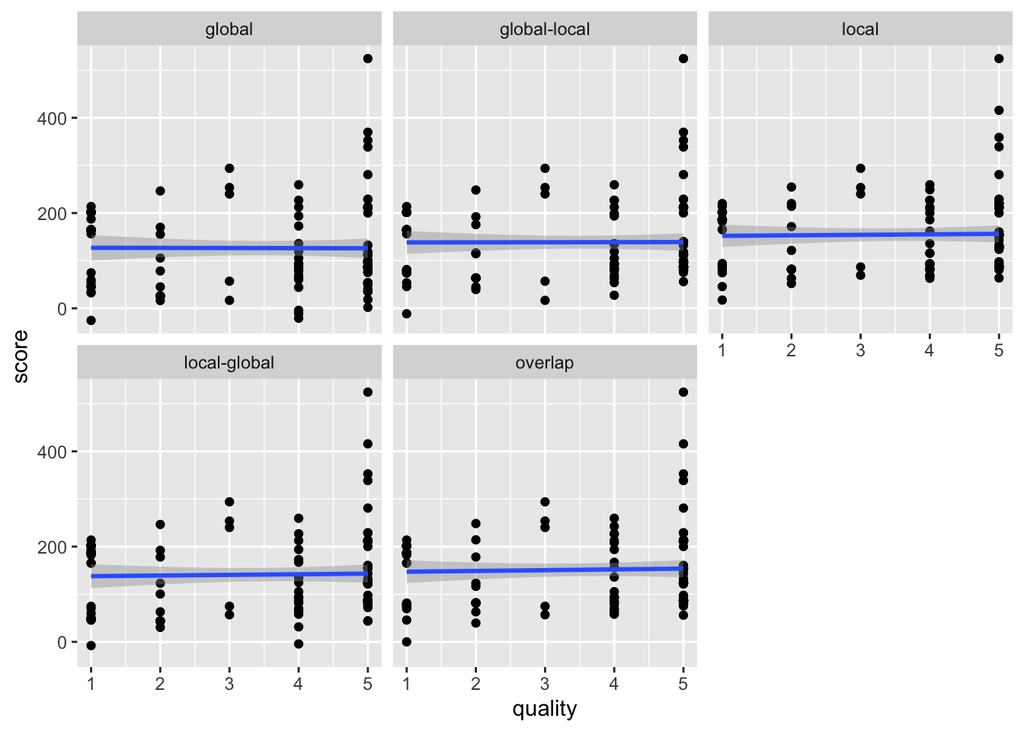

```r
label_align_all |>
    dplyr::select(quality, dplyr::ends_with("score")) |>
    tidyr::pivot_longer(
        cols = dplyr::ends_with("score"),
        names_to = c("type", ".value"),
        names_pattern = "([^_]+)_(.+)"
    ) |>
    ggplot2::ggplot(ggplot2::aes(x = quality, y = score)) +
    ggplot2::geom_point() +
    ggplot2::geom_smooth(method = "lm", formula = y ~ x) +
    ggplot2::facet_wrap(~ type)
```

### Attempting Length Normalization

I wonder if a simple length correction would improve the situation at all? I’ll use the sum of the label lengths.

**Show sl_normalize() function.**

```r
#' @param ... The strings to use for the correction. All string lengths will be
#' calculated and summed.
sl_normalize <- function(score, ...) {
    .l <- list(...)
    .l_len <- purrr::map(.l, length) |>
        unique()
    stopifnot(
        "`score` and all inputs to `...` must be the same length" =
            length(.l_len) == 1 && .l_len == length(score)
    )
    str_len <- purrr::map(.l, stringr::str_length)
    denom <- purrr::pmap(str_len, sum) |>
        unlist()
    score / denom
}
```

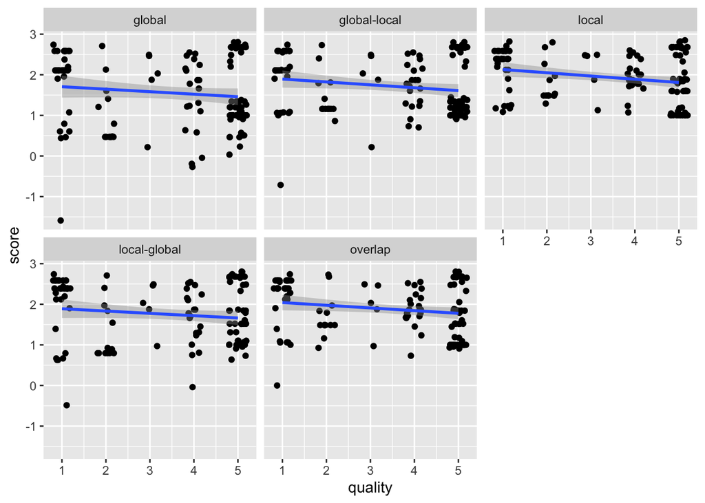

```r
label_align_all <- label_align_all |>
    dplyr::mutate(
        dplyr::across(
            dplyr::ends_with("score"),
            ~ sl_normalize(.x, .data$label, .data$google_translate_to_en),
            .names = "{.col}.std"
        )
    )

label_align_all |>
    dplyr::select(quality, dplyr::ends_with(".std")) |>
    tidyr::pivot_longer(
        cols = dplyr::ends_with(".std"),
        names_to = c("type", ".value"),
        names_pattern = "([^_]+)_(.+).std"
    ) |>
    ggplot2::ggplot(ggplot2::aes(x = quality, y = score)) +
    ggplot2::geom_jitter(width = 0.2, height = 0) +
    ggplot2::geom_smooth(method = "lm", formula = y ~ x) +
    ggplot2::facet_wrap(~ type)
```

Not in any significant way.

## Word-based Comparison

For word-based comparison, I’ll calculate the percentage of words in common. This approach does not account for word order and will be calculated as the count of words in the intersection of the original and backtranslated English divided by the count of the union between the two.

$$\frac{c(original \cap backtranslation)}{c(original \cup backtranslation)} \%$$
There may be differences due to “stop words” (common words that add little meaning) and conjugation, so I’ll look into how comparisons after dropping stop words and/or stemming change the results.

I’ll also attempt to identify “exact matches”, meaning they have all words in common, after any combination of the transformations listed above (and will indicate which is needed to generate the “exact match”).

```r
label_wcomp <- read_scomp_file() |>
    dplyr::select(-dplyr::starts_with("en_")) |>
    dplyr::mutate(id = dplyr::row_number(), .before = 1) |>
    dplyr::mutate(
        pct = word_similar(
            label,
            google_translate_to_en,
        ),
        pct_no_sw = word_similar(
            label,
            google_translate_to_en,
            stopwords = stopwords::stopwords()
        ),
        pct_stem = word_similar(
            label,
            google_translate_to_en,
            stem_words = TRUE
        ),
        pct_stem_no_sw = word_similar(
            label,
            google_translate_to_en,
            stopwords = stopwords::stopwords(),
            stem_words = TRUE
        ),
        # retain automated string matches first, then automated word matches,
        #   drop manually curated matches for this column at the moment (to be
        #   able to see more easily what automated approaches can't identify)
        wmatch_en = dplyr::case_when(
            !is.na(label_scomp$match_en) ~ "str_matched",
            pct == 100 ~ "all_words",
            pct_no_sw == 100 ~ "stopwords|all_words",
            pct_stem == 100 ~ "stemmed|all_words",
            pct_stem_no_sw == 100 ~ "stemmed|stopwords|all_words",
            .default = NA_character_
        )
    )
```

Grouping all the previous string-based transformation matches into a `str_matched` category, it looks like about 2/3 of the label matches are near-exact based on word transformations, with stop word removal being more important than stemming.

```r
dplyr::count(label_wcomp, wmatch_en)
```

| wmatch_en | n |
| --- | --- |
| all_words | 30 |
| stemmed\|all_words | 7 |
| stopwords\|all_words | 32 |
| str_matched | 417 |
| NA | 47 |

I want to note here that **punctuation is also removed and case ignored** for these word matches. It would be more complete to distinguish these but it’s a lot of effort for little gain.

The distribution of word match percentages, again ignoring string-based matches, shows improvement with each modification and that most matches contain 2/3 or more words (based on q25, percent stemmed without stop words… but similar in all).

```r
label_wcomp |>
    dplyr::filter(is.na(wmatch_en) | wmatch_en != "str_matched") |>
    col_summary(dplyr::starts_with("pct"), digits = 2)
```

| stat | pct | pct_no_sw | pct_stem | pct_stem_no_sw |
| --- | --- | --- | --- | --- |
| min | 0.00 | 0.00 | 0.00 | 0.00 |
| q25 | 56.75 | 61.88 | 66.67 | 66.67 |
| mean | 74.49 | 79.70 | 77.74 | 83.15 |
| q75 | 100.00 | 100.00 | 100.00 | 100.00 |
| max | 100.00 | 100.00 | 100.00 | 100.00 |
| median | 83.33 | 100.00 | 83.33 | 100.00 |

Using all word-based similarity scores, including those for previous string-based matches, doesn’t produce very good results.

```r
label_wcomp |>
    dplyr::summarize(
        dplyr::across(
            dplyr::starts_with("pct"),
            ~ cor(.x, quality) ^ 2
        )
    ) |>
    tidyr::pivot_longer(
        cols = dplyr::everything(),
        names_to = "transformation",
        values_to = "r-squared",
        names_pattern = "pct_?(.+)"
    )
```

| transformation | r-squared |
| --- | --- |
| NA | 0.3225941 |
| no_sw | 0.2999362 |
| stem | 0.3506103 |
| stem_no_sw | 0.3303801 |

If I try removing the string-based matches, the correlations get even worse.

```r
label_wcomp |>
    dplyr::filter(is.na(wmatch_en) | wmatch_en != "str_matched") |>
    dplyr::summarize(
        dplyr::across(
            dplyr::starts_with("pct"),
            ~ cor(.x, quality) ^ 2
        )
    ) |>
    tidyr::pivot_longer(
        cols = dplyr::everything(),
        names_to = "transformation",
        values_to = "r-squared",
        names_pattern = "pct_?(.+)"
    )
```

| transformation | r-squared |
| --- | --- |
| NA | 0.09203083 |
| no_sw | 0.13756869 |
| stem | 0.15741870 |
| stem_no_sw | 0.22415727 |

#### Plot

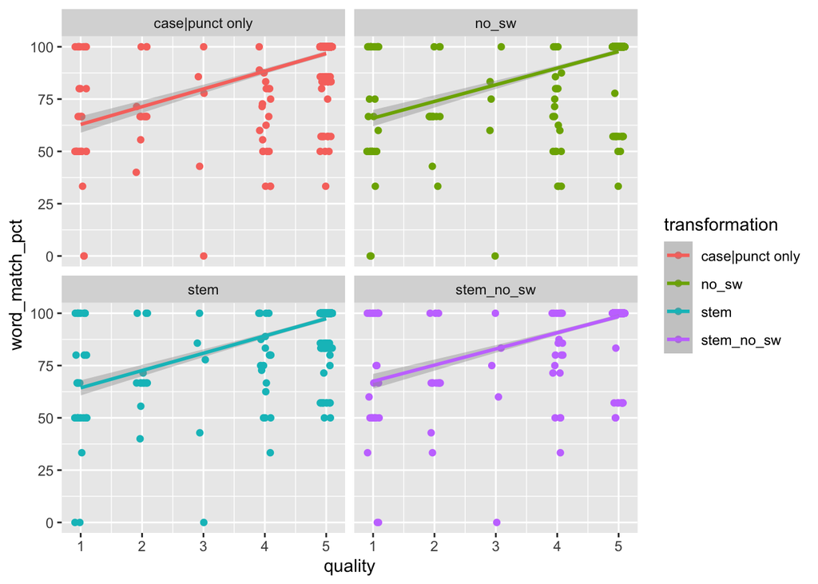

```r
label_wcomp |>
    dplyr::select(quality, dplyr::starts_with("pct")) |>
    tidyr::pivot_longer(
        cols = dplyr::starts_with("pct"),
        names_to = "transformation",
        values_to = "word_match_pct",
        names_pattern = "pct_?(.+)"
    ) |>
    dplyr::mutate(
        transformation = dplyr::if_else(
            is.na(transformation),
            "case|punct only",
            transformation
        )
    ) |>
    ggplot2::ggplot(
        ggplot2::aes(x = quality, y = word_match_pct, color = transformation)
    ) +
    ggplot2::geom_jitter(height = 0, width = 0.1) +
    ggplot2::geom_smooth(method = "lm", formula = y ~ x) +
    ggplot2::facet_wrap(~ transformation)
```

At least the expected trend is there. But, it really just doesn’t seem that any of these measures reflect my manual review well.

Best to see what happens for definitions, where very few exact matches exist between the original and backtranslated English.

# DEFINITIONS

## String-based Comparisons

First, I check to see how well string transformations identify near-exact matches and how well string-based comparisons perform for definitions. I’ll test `q` values of 1 & 4 for those qgram-based methods, since 1 is a true character-by-character measure and 4 performed the best with labels.

```r
def_init <- googlesheets4::with_gs4_quiet(
    googlesheets4::read_sheet(gs, "disorder_en_es_definition")
) |>
    # drop empty lines
    dplyr::filter(!dplyr::if_all(c("definition", "definición"), is.na))


# file to save to
sdef_file <- here::here("data/research/explore_stringdist_metrics-defs.csv")

def_scomp <- def_init |>
    dplyr::mutate(
        review_notes = NA,
        cause = NA,
        match_en = str_similar(definition, google_translate_to_en),
        quality = dplyr::if_else(!is.na(match_en), 5, NA_integer_),
        .before = 1
    ) |>
    dplyr::mutate(
        en_osa = stringdist::stringsim(definition, google_translate_to_en),
        en_dl = stringdist::stringsim(
            definition,
            google_translate_to_en,
            method = "dl"
        ),
        .after = google_translate_to_en
    ) |>
    qgram_vary(definition, google_translate_to_en, q = c(1, 4))

# save only first time script is run, to avoid overwriting manually added info
if (!file.exists(sdef_file)) {
    readr::write_csv(def_scomp, sdef_file, na = "")
}
```

```r
dplyr::count(def_scomp, match_en)
```

| match_en | n |
| --- | --- |
| exact | 7 |
| NA | 497 |

It’s not feasible to review all 497 non-exact definition matches. So I’ll first take a look at the distribution of the string distance metrics.

### Plot

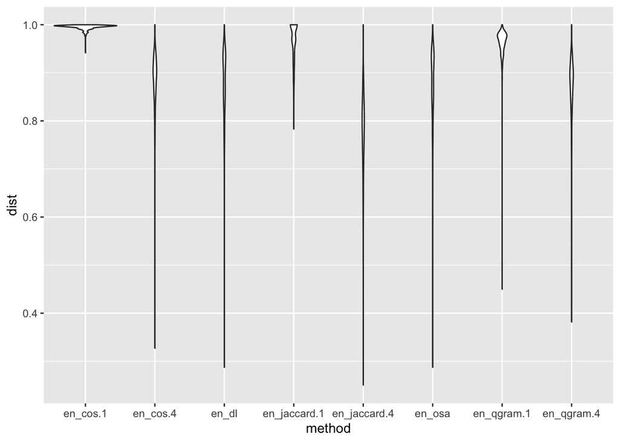

```r
def_scomp |>
    dplyr::select(dplyr::starts_with("en_")) |>
    tidyr::pivot_longer(
        cols = dplyr::starts_with("en_"),
        names_to = "method",
        values_to = "dist"
    ) |>
    ggplot2::ggplot(ggplot2::aes(x = method, y = dist)) +
    ggplot2::geom_violin()
```

Those violin plots just look similar to the previous distribution for labels. String distance metrics are just not likely to work well.

## Alignment

I just want to take a quick glance at alignments. They are likely to be better because definitions are longer… though the rearrangement of words may still be a big problem.

```r
def_galign <- pwalign::pairwiseAlignment(
    def_scomp$definition,
    def_scomp$google_translate_to_en,
    type = "global"
)

def_align <- def_scomp |>
    dplyr::mutate(
        g_align = paste0(
            as.character(pwalign::alignedPattern(def_galign)), "\n",
            as.character(pwalign::alignedSubject(def_galign))
        ),
        g_score = pwalign::score(def_galign)
    )
```

The first few alignments look as expected but it seems like there are more spaces than necessary because these are character-based alignments and not word-based alignments. I don’t know of any algorithms for word-based alignments, local alignment would probably handle it better but still not as desired.

```r
paste0(def_align$g_align, "\n\n") |>
    head() |>
    cat()
```

```
A hypothyroidism that is present at birth.
A hypothyroidism that is present at birth.

 A disease that has_----material_basis_in a genetic abnormality, ---error with embryonic development, ---infection- or --compromised intrauterine environment.
A disease that has its material basis in a genetic abnormality, an error with embryonic development, an infection, or a compromised intrauterine environment.

 A congenital ---------------nervous system abnormality characterized by the absence of folds in the cerebral cortex and caused_by defective neuronal migration during the-- 12th to 24th weeks of gestation.
C--ongenital anomaly of the nervous system ------------characterized by the absence of folds in the cerebral cortex and caused by defective neuronal migration during weeks 12-- to 24-------- of gestation.

 A congenital ---------------nervous system abnormality characterized by non prop----er migration of neurons during the early------------ development of the fetal brain.
C--ongenital anomaly of the nervous system ------------characterized by inappropriate- migration of neurons during ----early fetal brain development-------------------.

 A congenital syphilis that is manifest-----ed- during the first 3 months of life. The infection has_symptom skin lesions, has_symptom lymphadenopathy, has_symptom hepatosplenomegaly, has_symptom failure to --thr---ive, has_symptom blood-stained nasal discharge, has_symptom perioral fissures, has_sy…
A congenital syphilis that ---manifests itself during the first 3 months of life. The infection pre-sen-ts- skin lesions, ------------lymphadenopathy, h------------epatosplenomegaly, g----------------rowth retardation, ------------bloody------- nasal discharge, ------------perioral fissures, -------…

 A syphilis that results_in a multisystem infection in the fetus via---- the placenta.
S--yphilis that ca-uses--- a multisystem infection in the fetus through the placenta.
```

Alignments definitely *look* better for the definitions.

### Plot

I’m not sure if the distribution of alignment scores is meaningful since scores are higher for longer alignments. I wonder how it would look after length correction?

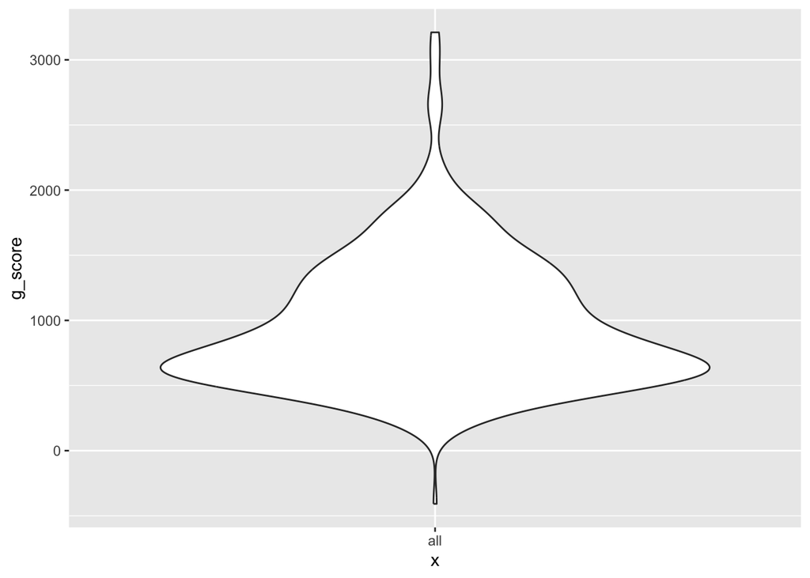

```r
ggplot2::ggplot(def_align, ggplot2::aes(x = "all", y = g_score)) +
    ggplot2::geom_violin()
```

That certainly changed the distribution.

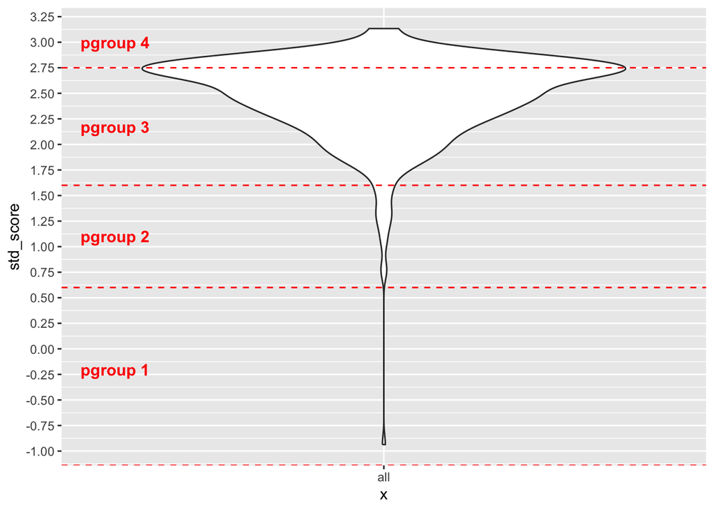

```r
def_align <- def_align |>
    dplyr::mutate(
        std_score = sl_normalize(
            g_score,
            .data$definition,
            .data$google_translate_to_en
        )
    )

splits <- c(-Inf, 0.6, 1.6, 2.75)
glabel_y_pos <- (c(splits[-1], 3.25) - c(-1, splits[-1])) / 2 + c(-1, splits[-1])

ggplot2::ggplot(def_align, ggplot2::aes(x = "all", y = std_score)) +
    ggplot2::geom_violin() +
    ggplot2::scale_y_continuous(n.breaks = 20) +
    ggplot2::geom_hline(
        yintercept = splits,
        color = "red",
        linetype = "dashed"
    ) +
    ggplot2::annotate(
        geom = "text",
        x = rep(0.5, 4), y = glabel_y_pos,
        label = paste("pgroup", 1:4),
        size = 4, fontface = "bold", color = "red"
    )
```

I wonder if I partition these at normalized alignment scores as indicated on the plot if I’d notice any obvious patterns (groups 1-4 identified by lowest value: -Inf, 0.6, 1.6, 2.75).

Most of these examples actually look pretty good, maybe alignment is a decent approach after all. It looks like the number of mismatches does vary by group with the fewest errors in group 4 (highest scores). At least this could help us identify which definitions to focus on for correction. It’s definitely not perfect because I saw the substitution in a group 3 of “acanthosis” for “ichthyosis”. That change does open a gap but the lack of meaning doesn’t allow it to be as big of a hit to the score as it should be.

```r
def_align <- def_align |>
    dplyr::mutate(pgroup = findInterval(.data$std_score, splits))
```

```r
dplyr::count(def_align, pgroup)
```

| pgroup | n |
| --- | --- |
| 1 | 1 |
| 2 | 15 |
| 3 | 364 |
| 4 | 124 |

```r
pgroup_print <- def_align |>
    dplyr::select(pgroup, g_align) |>
    dplyr::group_by(.data$pgroup) |>
    dplyr::slice_sample(n = 5) |>
    dplyr::group_split(.keep = FALSE)

for (i in 1:length(pgroup_print)) {
    print(paste0("pgroup", i))
    cat(paste0(pgroup_print[[i]]$g_align, "\n\n"))
}
```

```
[1] "pgroup1"
A multiple congenital anomalies-hypotonia-seizures syndrome that is characterized by X-linked recessive inheritance of dysmorphic features, neonatal hypotonia, myoclonic seizures and variable abnormalities involving the central nervous, cardiac, and urinary systems that has_material_basis_in mutatio…
A multiple congenital anomaly---hypotonia-seizure- syndrome --------characterized by -----------------------------------------------------------------------------------------------------------------------------------------------------------------------------------------------------------------------…

[1] "pgroup2"
A non-syndromic congenital nail disorder that is characterized by nails with longi- tudinal streak---s, thinning of the nail plate, poo-rly developed or absent lunulae, along----- with variously disturbed formation of the nail plate ----------leading to increased vulnerability of the free nail margi…
N--on-syndromic congenital nail disorder --------characterized by nails with longi--tudinal striations, thinning of the nail plate, under---developed or absent lunules, t-o-gether with variously al-ter-ed -----------------nail plate formation leading to increased vulnerability of the free -----margi…

 A congenital syphilis that is manifest-----ed- during the first 3 months of life. The infection has_symptom skin lesions, has_symptom lymphadenopathy, has_symptom hepatosplenomegaly, has_symptom failure to --thr---ive, has_symptom blood-stained nasal discharge, has_symptom perioral fissures, has_sy…
A congenital syphilis that ---manifests itself during the first 3 months of life. The infection pre-sen-ts- skin lesions, ------------lymphadenopathy, h------------epatosplenomegaly, g----------------rowth retardation, ------------bloody------- nasal discharge, ------------perioral fissures, -------…

 A diarrhea that is characterized by frequent loose-- or liquid bowel movements where the disease is present from birth.
D--iarrhea-------- characterized by frequent wat-ery or soft stoo--l---------s when- the disease is present from birth.

 A ptosis characterized by-------------------- eyelid drop present at birth.
A ptosis characterized by the drooping of the eyelid -----present at birth.

 A holoprosencephaly that has_---------material_basis_in mutation in the ---homeobox----containing SIX3 gene---- on chromosome 2p21.
A holoprosencephaly that has_its_base_material_------in mutation in the SIX3 gene that contains------- homeobox on chromosome 2p21.

[1] "pgroup3"
An eyelid disease that is characterized by a---bnormal narrow-ness of the palpebral fissure in the horizontal direction caused by the lateral displacement of the medial canthi- of the eyelids.
E---yelid disease --------characterized by an abnormal narrowing-- of the palpebral fissure in a-- horizontal direction caused by ----lateral displacement of the medial canthus of the eyelids.

 A congenital disorder of glycosylation I that is characterized by developmental delay, intellectual disability, failure to --thr---ive, hypotonia- and seizures and has_----material_basis_in --homozygous mutation in the STT3A gene on chromosome 11q24.
A congenital disorder of glycosylation I --------characterized by developmental delay, intellectual disability, g----rowth retardation, hypotonia, and seizures and has its material basis in a homozygous mutation in the STT3A gene on chromosome 11q24.

 A congenital myasthenic syndrome characterized by a---utosomal recessive inheritance of onset of proximal muscle weakness in the first decade that generally responds well to ---------------acetylcholinesterase inhibitor treatment that has_---------material_basis_in homozygous or compound heterozygo…
C--ongenital myasthenic syndrome characterized by an autosomal recessive inheritance of onset of proximal muscle weakness in the first decade that generally responds well to treatment with acetylcholinesterase inhibitors--------- that has_its_base_material_------in homozygous or compound heterozygou…

 A congenital disorder of glycosylation that involves --malfunctioning trimming or processing of the protein-bound oligosaccharide chain------------------------.
A congenital disorder of glycosylation that involves a malfunction of trimming or processing of the-------------- oligosaccharide chain attached to the protein.

 A multiple congenital anomalies-hypotonia-seizures syndrome that is characterized by neonatal hypotonia, lack of psychomotor development, seizures, dysmorphic features, and variable congenital anomalies involving the cardiac, urinary, and gastrointestinal systems and has_----material_basis_in --hom…
```

[output cut: 17 more lines]

## Word-based Comparison

### Examining Stop Words

Wording in definitions is quite important so, before I do any testing, I’ll try to develop a meaningful list of stop words.

```r
def_words <- def_init |>
    dplyr::select(class, definition) |>
    tidytext::unnest_tokens(output = word, input = definition) |>
    dplyr::count(word, sort = TRUE) |>
    dplyr::mutate(pct = round(n / sum(n) * 100, 2))

def_words
```

| word | n | pct |
| --- | --- | --- |
| the | 613 | 4.70 |
| a | 528 | 4.05 |
| that | 502 | 3.85 |
| in | 477 | 3.66 |
| and | 394 | 3.02 |
| has_material_basis_in | 391 | 3.00 |
| mutation | 367 | 2.81 |
| on | 366 | 2.81 |
| of | 365 | 2.80 |
| chromosome | 349 | 2.67 |

[output cut: 2187 more lines]

Some of the most common words (e.g. has_material_basis_in) are really important. It looks like most of the high count words that we’d consider removing are similar to those in `stopwords::stopwords()` anyway… so maybe we should just use that?

Overlap in frequent words in definitions and `stopwords()`:

```r
def_words[def_words$word %in% stopwords::stopwords(), ]
```

| word | n | pct |
| --- | --- | --- |
| the | 613 | 4.70 |
| a | 528 | 4.05 |
| that | 502 | 3.85 |
| in | 477 | 3.66 |
| and | 394 | 3.02 |
| on | 366 | 2.81 |
| of | 365 | 2.80 |
| by | 310 | 2.38 |
| or | 223 | 1.71 |
| is | 137 | 1.05 |

[output cut: 50 more lines]

Frequent words that do NOT occur in `stopwords()`:

```r
def_words[!def_words$word %in% stopwords::stopwords(), ]
```

| word | n | pct |
| --- | --- | --- |
| has_material_basis_in | 391 | 3.00 |
| mutation | 367 | 2.81 |
| chromosome | 349 | 2.67 |
| gene | 325 | 2.49 |
| characterized | 300 | 2.30 |
| congenital | 280 | 2.15 |
| heterozygous | 244 | 1.87 |
| homozygous | 183 | 1.40 |
| compound | 155 | 1.19 |
| autosomal | 120 | 0.92 |

[output cut: 2127 more lines]

Full set of stopwords():

```r
stopwords::stopwords()
```

```
  [1] "i"          "me"         "my"         "myself"     "we"
  [6] "our"        "ours"       "ourselves"  "you"        "your"
 [11] "yours"      "yourself"   "yourselves" "he"         "him"
 [16] "his"        "himself"    "she"        "her"        "hers"
 [21] "herself"    "it"         "its"        "itself"     "they"
 [26] "them"       "their"      "theirs"     "themselves" "what"
 [31] "which"      "who"        "whom"       "this"       "that"
 [36] "these"      "those"      "am"         "is"         "are"
 [41] "was"        "were"       "be"         "been"       "being"
 [46] "have"       "has"        "had"        "having"     "do"
 [51] "does"       "did"        "doing"      "would"      "should"
 [56] "could"      "ought"      "i'm"        "you're"     "he's"
 [61] "she's"      "it's"       "we're"      "they're"    "i've"
 [66] "you've"     "we've"      "they've"    "i'd"        "you'd"
 [71] "he'd"       "she'd"      "we'd"       "they'd"     "i'll"
```

[output cut: 20 more lines]

After looking at these sets of words, I don’t think any of the words in `stopwords()` will likely be important, so I’ll just stick with that.

### Word Similarity

Calculating the word similarity percentage (including punctuation removal and case-insensitivity, of course).

```r
def_wcomp <- def_scomp |>
    dplyr::select(-dplyr::starts_with("en_")) |>
    dplyr::mutate(id = dplyr::row_number(), .before = 1) |>
    dplyr::mutate(
        pct = word_similar(
            definition,
            google_translate_to_en,
        ),
        pct_no_sw = word_similar(
            definition,
            google_translate_to_en,
            stopwords = stopwords::stopwords()
        ),
        pct_stem = word_similar(
            definition,
            google_translate_to_en,
            stem_words = TRUE
        ),
        pct_stem_no_sw = word_similar(
            definition,
            google_translate_to_en,
            stopwords = stopwords::stopwords(),
            stem_words = TRUE
        ),
        match_en = dplyr::case_when(
            !is.na(match_en) ~ match_en,
            pct == 100 ~ "all_words",
            pct_no_sw == 100 ~ "stopwords|all_words",
            pct_stem == 100 ~ "stemmed|all_words",
            pct_stem_no_sw == 100 ~ "stemmed|stopwords|all_words",
            .default = NA_character_
        )
    )
```

```r
dplyr::count(def_wcomp, match_en)
```

| match_en | n |
| --- | --- |
| all_words | 1 |
| exact | 7 |
| stemmed\|stopwords\|all_words | 4 |
| stopwords\|all_words | 18 |
| NA | 474 |

Very few definitions are exact or near-exact matches for words, even with all word transformations.

```r
col_summary(def_wcomp, dplyr::starts_with("pct"), digits = 2)
```

| stat | pct | pct_no_sw | pct_stem | pct_stem_no_sw |
| --- | --- | --- | --- | --- |
| min | 27.50 | 25.81 | 34.21 | 34.48 |
| q25 | 75.00 | 75.00 | 76.92 | 77.78 |
| mean | 80.47 | 80.49 | 81.70 | 82.32 |
| q75 | 87.50 | 86.25 | 88.00 | 87.72 |
| max | 100.00 | 100.00 | 100.00 | 100.00 |
| median | 81.25 | 81.82 | 83.33 | 83.33 |

#### Plot

There’s a sort of bimodal distribution here that’s dependent on the presence of stop words, which is interesting.

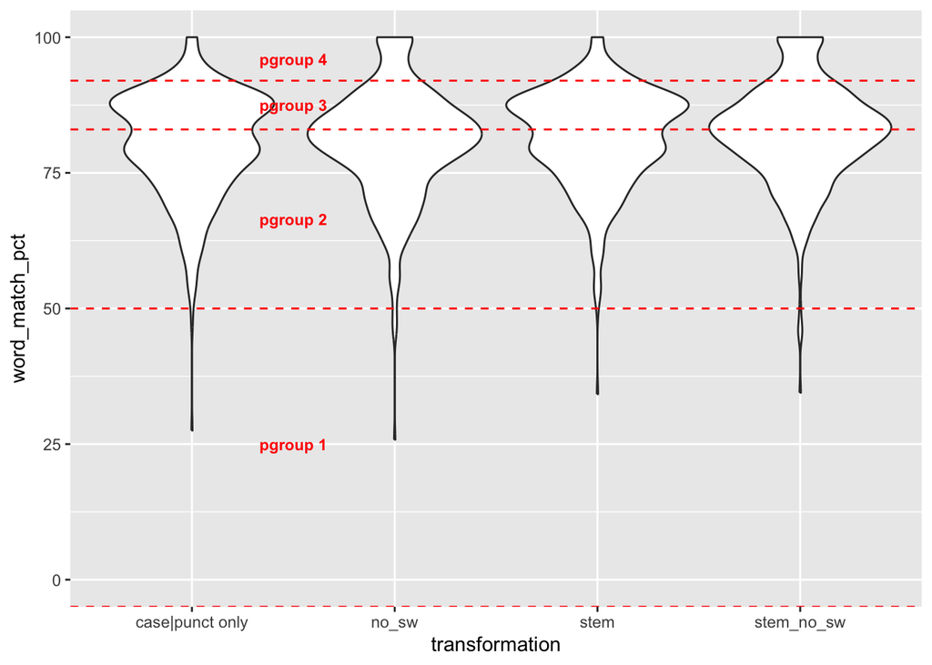

```r
wsplits <- c(-Inf, 50, 83, 92)
glabel_y_pos <- (c(wsplits[-1], 100) - c(0, wsplits[-1])) / 2 + c(0, wsplits[-1])

def_wcomp |>
    dplyr::select(dplyr::starts_with("pct")) |>
    tidyr::pivot_longer(
        cols = dplyr::everything(),
        names_to = "transformation",
        values_to = "word_match_pct",
        names_pattern = "pct_?(.+)"
    ) |>
    dplyr::mutate(
        transformation = dplyr::if_else(
            is.na(transformation),
            "case|punct only",
            transformation
        )
    ) |>
    ggplot2::ggplot(ggplot2::aes(x = transformation, y = word_match_pct)) +
    ggplot2::geom_violin() +
    ggplot2::geom_hline(
        yintercept = wsplits,
        color = "red",
        linetype = "dashed"
    ) +
    ggplot2::annotate(
        geom = "text",
        x = rep(1.5, 4), y = glabel_y_pos,
        label = paste("pgroup", 1:4),
        size = 3, fontface = "bold", color = "red"
    ) +
    ggplot2::ylim(0, 100)
```

```r
def_wcomp <- def_wcomp |>
    dplyr::mutate(pgroup = findInterval(.data$pct, wsplits))
```

```r
dplyr::count(def_wcomp, pgroup)
```

| pgroup | n |
| --- | --- |
| 1 | 2 |
| 2 | 276 |
| 3 | 196 |
| 4 | 30 |

Hmm… as I review all the examples, I cannot really tell a great difference between the groups. Almost across the board, translation is pretty good. This of course, suggests that percent word similarity is not very meaningful.

```r
pgroup_print <- def_wcomp |>
    dplyr::group_by(.data$pgroup) |>
    dplyr::slice_sample(n = 5) |>
    dplyr::mutate(out = paste(definition, google_translate_to_en, sep = "\n---\n")) |>
    dplyr::group_split(.keep = FALSE)


for (i in 1:length(pgroup_print)) {
    print(paste0("pgroup", i))
    cat(paste0(pgroup_print[[i]]$out, "\n\n"))
}
```

```
[1] "pgroup1"
A multiple congenital anomalies-hypotonia-seizures syndrome that is characterized by X-linked recessive inheritance of dysmorphic features, neonatal hypotonia, myoclonic seizures and variable abnormalities involving the central nervous, cardiac, and urinary systems that has_material_basis_in mutatio…
---
A multiple congenital anomaly-hypotonia-seizure syndrome characterized by PIGA on chromosome Xp22.

 A nonsyndromic congenital nail disorder that is characterized by partial absences of nails.
---
Non-syndromic congenital nail disorder characterized by the partial absence of nails.

[1] "pgroup2"
An orofacial cleft that has_material_basis_in variation in an enhancer of the IRF6 gene on chromosome 1q32.
---
An orofacial cleft that has_its_base_material_in the variation of an enhancer of the IRF6 gene on chromosome 1q32.

 An orofacial cleft that is characterized by a congenital defect in the upper lip where the maxillary prominence fails to merge with the merged medial nasal prominences.
---
Orofacial cleft characterized by a congenital defect in the upper lip in which the maxillary prominence fails to fuse with the fused middle nasal prominences.

 A congenital dyserythropoietic anemia type I that has_material_basis_in homozygous or compound heterozygous mutation in C15orf41 on chromosome 15q14.
---
A congenital dyserythropoietic anemia type I that has a homozygous or compound heterozygous mutation at C15orf41 on chromosome 15q14.

 An atrial heart septal defect that has_material_basis_in heterozygous mutation in the CITED2 gene on chromosome 6q23.3.
---
An atrial septal defect that has_its_material_base_in a heterozygous mutation in the CITED2 gene on chromosome 6q23.3.

 A pleural disease characterized by the accumulation of chyle within the pleural space leading to respiratory distress, malnutrition and immunological compromise, either immediately after birth or within the first few weeks of life.
---
Pleural disease characterized by the accumulation of chyle in the pleural space that causes respiratory distress, malnutrition, and immunocompromise, either immediately after birth or in the first weeks of life.

[1] "pgroup3"
A congenital myasthenic syndrome characterized by autosomal recessive inheritance of a defect within the synapse at the neuromuscular junction resulting in prolonged synaptic currents and action potentials that has_material_basis_in homozygous or compound heterozygous mutation in the COLQ gene on ch…
---
Congenital myasthenic syndrome characterized by the autosomal recessive inheritance of a defect in the synapse of the neuromuscular junction that causes synaptic currents and prolonged action potentials and that has_its_material_base_in a homozygous or compound heterozygous mutation in the COLQ gene…

 A muscular dystrophy-dystroglycanopathy characterized by limb-girdle congenital muscular dystrophy and cognitive impairment that has_material_basis_in homozygous or compound heterozygous mutation in the POMK gene on chromosome 8p11.21.
---
A muscular dystrophy-dystroglycanopathy characterized by congenital limb-girdle muscular dystrophy and cognitive impairment that has its material basis in a homozygous or compound heterozygous mutation in the POMK gene on chromosome 8p11.21.

 A congenital disorder of glycosylation type II that has_material_basis_in an autosomal recessive mutation of the CCDC115 gene on chromosome 2q21.1.
```

[output cut: 16 more lines]

```
 A severe congenital neutropenia characterized by neutropenia and neutrophil dysfunction, a lack of response to G-CSF, life-threatening infections, bone marrow fibrosis, and renal extramedullary hematopoiesis that has_material_basis_in homozygous or compound heterozygous mutation in the VPS45 gene o…
---
A severe congenital neutropenia characterized by neutropenia and neutrophil dysfunction, lack of response to G-CSF, life-threatening infections, bone marrow fibrosis, and renal extramedullary hematopoiesis that has a homozygous or compound heterozygous mutation in the VPS45 gene on chromosome 1q21.2…

 A congenital muscular dystrophy characterized by muscular dystrophy resulting from defective glycosylation of dystroglycan.
---
A congenital muscular dystrophy characterized by muscular dystrophy resulting from defective glycosylation of dystroglycan.

 A congenital hypothyroidism characterized by a small thyroid gland with low free T4 levels and inappropriately normal levels of thyroid-stimulating hormone that has_material_basis_in hemizygous mutation in the IRS4 gene on chromosome Xq22.3.
---
A congenital hypothyroidism characterized by a small thyroid gland with low levels of free T4 and inappropriately normal levels of thyroid-stimulating hormone that has a hemizygous mutation in the IRS4 gene on chromosome Xq22.3.

 A lissencephaly characterized by lissencephaly in combination with severe congenital microcephaly.
---
A lissencephaly characterized by lissencephaly in combination with severe congenital microcephaly.
```